# time-series

Rmd for performing time-series analyses with the individual crab RNAseq data sets. https://www.bioconductor.org/help/course-materials/2015/LearnBioconductorFeb2015/B02.1.1_RNASeqLab.html#time

```r
library(DESeq2)
library(tidyverse)
```

```r
library(pheatmap)
```

## Read in and prepare dataset:

FROM TRANSCRIPTOME V. 1.5 Read in the isoform count matrix from the 2020 Genewiz individual crab RNAseq data (un-normalized!!):

```r
indiv_counts <- read.delim("../data/individual_crab-salmon.isoform.counts.matrix")
head(indiv_counts)
```

```
##                          X X294_quant X254_quant X280_quant X485_quant
## 1  TRINITY_DN5772_c0_g1_i1          0          0      0.000          0
## 2  TRINITY_DN2201_c0_g1_i1          5          0      5.823          0
## 3  TRINITY_DN4656_c0_g1_i1         19         36      4.000         12
## 4  TRINITY_DN7591_c0_g1_i1         16          3      2.000          1
## 5  TRINITY_DN6285_c0_g1_i4          0          0      0.000          4
## 6 TRINITY_DN28918_c0_g1_i1          0          0      0.000          0
##   X481_quant X173_quant X222_quant X151_quant X272_quant X132_quant X127_quant
## 1          0          0          0          0          0          0          0
## 2          0          0          5          0          0          0          0
## 3          8         74          8         53          0          7         18
## 4         15          0         11         17          0          0         41
## 5          0          0          0          0          0          0          0
## 6          1          0          0          0          0          0          1
##   X73_quant X427_quant X118_quant X334_quant X349_quant X425_quant X178_quant
## 1         0          0          0          0          0          0          0
## 2         0          0          0          0          0          0          0
## 3         0          0          4          3          0          0         37
## 4         0          0          2          0          0          0          3
## 5         0          0          0          0          0          0          0
## 6         0          0          0          0          0          0          2
##   X72_quant X463_quant X221_quant X445_quant X359_quant X113_quant
## 1         0          0          0      0.000          3      0.000
## 2         0          0          0     80.000          0     28.449
## 3         7          0          0     20.000         35     14.000
## 4         0          0          0     38.000         25     36.000
## 5         0          0          0      5.946          0      0.000
## 6         0          0          0      0.000          0      0.000
```

Rename columns: Crab Letter (A-I based on table in paper) and sample day. Table in paper will tell infection status of the crabs.

```r
colnames(indiv_counts) <- c("X", "CrabH_2", "CrabE_2", "CrabI_2", "CrabC_17", "CrabB_17", "CrabG_0", "CrabF_2", "CrabE_0", "CrabG_2", "CrabC_0", "CrabI_0", "CrabD_0", "CrabD_17", "CrabB_0", "CrabC_2", "CrabB_2", "CrabF_17", "CrabA_0", "CrabH_0", "CrabA_17", "CrabD_2", "CrabE_17", "CrabA_2", "CrabF_0")
head(indiv_counts)
```

```
##                          X CrabH_2 CrabE_2 CrabI_2 CrabC_17 CrabB_17 CrabG_0
## 1  TRINITY_DN5772_c0_g1_i1       0       0   0.000        0        0       0
## 2  TRINITY_DN2201_c0_g1_i1       5       0   5.823        0        0       0
## 3  TRINITY_DN4656_c0_g1_i1      19      36   4.000       12        8      74
## 4  TRINITY_DN7591_c0_g1_i1      16       3   2.000        1       15       0
## 5  TRINITY_DN6285_c0_g1_i4       0       0   0.000        4        0       0
## 6 TRINITY_DN28918_c0_g1_i1       0       0   0.000        0        1       0
##   CrabF_2 CrabE_0 CrabG_2 CrabC_0 CrabI_0 CrabD_0 CrabD_17 CrabB_0 CrabC_2
## 1       0       0       0       0       0       0        0       0       0
## 2       5       0       0       0       0       0        0       0       0
## 3       8      53       0       7      18       0        0       4       3
## 4      11      17       0       0      41       0        0       2       0
## 5       0       0       0       0       0       0        0       0       0
## 6       0       0       0       0       1       0        0       0       0
##   CrabB_2 CrabF_17 CrabA_0 CrabH_0 CrabA_17 CrabD_2 CrabE_17 CrabA_2 CrabF_0
## 1       0        0       0       0        0       0    0.000       3   0.000
## 2       0        0       0       0        0       0   80.000       0  28.449
## 3       0        0      37       7        0       0   20.000      35  14.000
## 4       0        0       3       0        0       0   38.000      25  36.000
## 5       0        0       0       0        0       0    5.946       0   0.000
## 6       0        0       2       0        0       0    0.000       0   0.000
```

Make Column X (Trinity IDs) row names:

```r
rownames(indiv_counts) <- indiv_counts$X
indiv_counts <- indiv_counts[,-1]
head(indiv_counts)
```

```
##                          CrabH_2 CrabE_2 CrabI_2 CrabC_17 CrabB_17 CrabG_0
## TRINITY_DN5772_c0_g1_i1        0       0   0.000        0        0       0
## TRINITY_DN2201_c0_g1_i1        5       0   5.823        0        0       0
## TRINITY_DN4656_c0_g1_i1       19      36   4.000       12        8      74
## TRINITY_DN7591_c0_g1_i1       16       3   2.000        1       15       0
## TRINITY_DN6285_c0_g1_i4        0       0   0.000        4        0       0
## TRINITY_DN28918_c0_g1_i1       0       0   0.000        0        1       0
##                          CrabF_2 CrabE_0 CrabG_2 CrabC_0 CrabI_0 CrabD_0
## TRINITY_DN5772_c0_g1_i1        0       0       0       0       0       0
## TRINITY_DN2201_c0_g1_i1        5       0       0       0       0       0
## TRINITY_DN4656_c0_g1_i1        8      53       0       7      18       0
## TRINITY_DN7591_c0_g1_i1       11      17       0       0      41       0
## TRINITY_DN6285_c0_g1_i4        0       0       0       0       0       0
## TRINITY_DN28918_c0_g1_i1       0       0       0       0       1       0
##                          CrabD_17 CrabB_0 CrabC_2 CrabB_2 CrabF_17 CrabA_0
## TRINITY_DN5772_c0_g1_i1         0       0       0       0        0       0
## TRINITY_DN2201_c0_g1_i1         0       0       0       0        0       0
## TRINITY_DN4656_c0_g1_i1         0       4       3       0        0      37
## TRINITY_DN7591_c0_g1_i1         0       2       0       0        0       3
## TRINITY_DN6285_c0_g1_i4         0       0       0       0        0       0
## TRINITY_DN28918_c0_g1_i1        0       0       0       0        0       2
##                          CrabH_0 CrabA_17 CrabD_2 CrabE_17 CrabA_2 CrabF_0
## TRINITY_DN5772_c0_g1_i1        0        0       0    0.000       3   0.000
## TRINITY_DN2201_c0_g1_i1        0        0       0   80.000       0  28.449
## TRINITY_DN4656_c0_g1_i1        7        0       0   20.000      35  14.000
## TRINITY_DN7591_c0_g1_i1        0        0       0   38.000      25  36.000
## TRINITY_DN6285_c0_g1_i4        0        0       0    5.946       0   0.000
## TRINITY_DN28918_c0_g1_i1       0        0       0    0.000       0   0.000
```

Round counts up to integers!!!

```r
indiv_counts <- round(indiv_counts,0)
head(indiv_counts)
```

```
##                          CrabH_2 CrabE_2 CrabI_2 CrabC_17 CrabB_17 CrabG_0
## TRINITY_DN5772_c0_g1_i1        0       0       0        0        0       0
## TRINITY_DN2201_c0_g1_i1        5       0       6        0        0       0
## TRINITY_DN4656_c0_g1_i1       19      36       4       12        8      74
## TRINITY_DN7591_c0_g1_i1       16       3       2        1       15       0
## TRINITY_DN6285_c0_g1_i4        0       0       0        4        0       0
## TRINITY_DN28918_c0_g1_i1       0       0       0        0        1       0
##                          CrabF_2 CrabE_0 CrabG_2 CrabC_0 CrabI_0 CrabD_0
## TRINITY_DN5772_c0_g1_i1        0       0       0       0       0       0
## TRINITY_DN2201_c0_g1_i1        5       0       0       0       0       0
## TRINITY_DN4656_c0_g1_i1        8      53       0       7      18       0
## TRINITY_DN7591_c0_g1_i1       11      17       0       0      41       0
## TRINITY_DN6285_c0_g1_i4        0       0       0       0       0       0
## TRINITY_DN28918_c0_g1_i1       0       0       0       0       1       0
##                          CrabD_17 CrabB_0 CrabC_2 CrabB_2 CrabF_17 CrabA_0
## TRINITY_DN5772_c0_g1_i1         0       0       0       0        0       0
## TRINITY_DN2201_c0_g1_i1         0       0       0       0        0       0
## TRINITY_DN4656_c0_g1_i1         0       4       3       0        0      37
## TRINITY_DN7591_c0_g1_i1         0       2       0       0        0       3
## TRINITY_DN6285_c0_g1_i4         0       0       0       0        0       0
## TRINITY_DN28918_c0_g1_i1        0       0       0       0        0       2
##                          CrabH_0 CrabA_17 CrabD_2 CrabE_17 CrabA_2 CrabF_0
## TRINITY_DN5772_c0_g1_i1        0        0       0        0       3       0
## TRINITY_DN2201_c0_g1_i1        0        0       0       80       0      28
## TRINITY_DN4656_c0_g1_i1        7        0       0       20      35      14
## TRINITY_DN7591_c0_g1_i1        0        0       0       38      25      36
## TRINITY_DN6285_c0_g1_i4        0        0       0        6       0       0
## TRINITY_DN28918_c0_g1_i1       0        0       0        0       0       0
```

## `DESeq2` analyses on some samples:

I’m not going to do it on all samples at once.

I’ll start with ABC vs GHI time points 0 and 2. Kinda weird because at time 0 all samples are at ambient… but that’s all I can do. Subset those columns:

```r
abcghi <- select(indiv_counts, CrabA_0, CrabB_0, CrabC_0, CrabA_2, CrabB_2, CrabC_2, CrabG_0, CrabH_0, CrabI_0, CrabG_2, CrabH_2, CrabI_2)
head(abcghi)
```

```
##                          CrabA_0 CrabB_0 CrabC_0 CrabA_2 CrabB_2 CrabC_2
## TRINITY_DN5772_c0_g1_i1        0       0       0       3       0       0
## TRINITY_DN2201_c0_g1_i1        0       0       0       0       0       0
## TRINITY_DN4656_c0_g1_i1       37       4       7      35       0       3
## TRINITY_DN7591_c0_g1_i1        3       2       0      25       0       0
## TRINITY_DN6285_c0_g1_i4        0       0       0       0       0       0
## TRINITY_DN28918_c0_g1_i1       2       0       0       0       0       0
##                          CrabG_0 CrabH_0 CrabI_0 CrabG_2 CrabH_2 CrabI_2
## TRINITY_DN5772_c0_g1_i1        0       0       0       0       0       0
## TRINITY_DN2201_c0_g1_i1        0       0       0       0       5       6
## TRINITY_DN4656_c0_g1_i1       74       7      18       0      19       4
## TRINITY_DN7591_c0_g1_i1        0       0      41       0      16       2
## TRINITY_DN6285_c0_g1_i4        0       0       0       0       0       0
## TRINITY_DN28918_c0_g1_i1       0       0       1       0       0       0
```

```r
abcghi.colData <- data.frame(temperature=factor(c(rep("ambient", 6), rep("elevated", 6))),
                             day=factor(c(rep("day0", 3), rep("day2", 3), rep("day0", 3), rep("day2", 3))))
rownames(abcghi.colData) <- colnames(abcghi)
abcghi.dds <- DESeqDataSetFromMatrix(countData = abcghi,
                                     colData = abcghi.colData,
                                     design = ~ temperature + day + temperature:day)
```

Check levels of temperature and day:

```r
levels(abcghi.dds$temperature)
```

```
## [1] "ambient"  "elevated"
```

```r
levels(abcghi.dds$day)
```

```
## [1] "day0" "day2"
```

```r
design(abcghi.dds) <- formula(~ temperature + day)
abcghi.dds <- DESeq(abcghi.dds)
abcghi.res <- results(abcghi.dds)
abcghi.res$symbol <- mcols(abcghi.dds)$symbol
head(abcghi.res[order(abcghi.res$pvalue),],4)
```

```
## log2 fold change (MLE): day day2 vs day0
## Wald test p-value: day day2 vs day0
## DataFrame with 4 rows and 6 columns
##                                 baseMean    log2FoldChange            lfcSE
##                                <numeric>         <numeric>        <numeric>
## TRINITY_DN1501_c0_g1_i6 411.467424711977  27.2783224050561 2.77677578464326
## TRINITY_DN699_c0_g1_i16 569.368837800508  27.6586636885024 3.00380562188393
## TRINITY_DN369_c0_g1_i6  6.95834301784196 -21.9959386553564 3.05905320909051
## TRINITY_DN668_c0_g1_i13 394.698264215112  11.8281849234669 2.26572874519641
##                                      stat               pvalue
##                                 <numeric>            <numeric>
## TRINITY_DN1501_c0_g1_i6  9.82373966091059 8.89800439847936e-23
## TRINITY_DN699_c0_g1_i16  9.20787400056714 3.32647855287441e-20
## TRINITY_DN369_c0_g1_i6  -7.19044003222682 6.45828384700334e-13
## TRINITY_DN668_c0_g1_i13  5.22047705337364 1.78462819565835e-07
##                                         padj
##                                    <numeric>
## TRINITY_DN1501_c0_g1_i6 6.16186804594696e-19
## TRINITY_DN699_c0_g1_i16 1.15179319893276e-16
## TRINITY_DN369_c0_g1_i6                    NA
## TRINITY_DN668_c0_g1_i13  0.00041195167516447
```

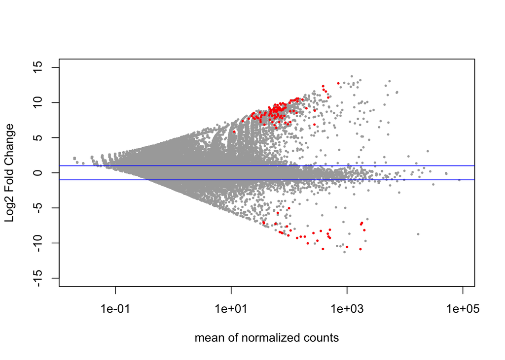

```r
abcghi.res <- abcghi.res
# The main plot
plot(abcghi.res$baseMean, abcghi.res$log2FoldChange, pch=20, cex=0.45, ylim=c(-15, 15), log="x", col="darkgray",
     #main="Infection Status  (pval </= 0.05)",
     xlab="mean of normalized counts",
     ylab="Log2 Fold Change")
# Getting the significant points and plotting them again so they're a different color
abcghi.res.sig <- abcghi.res[!is.na(abcghi.res$padj) & abcghi.res$padj <= 0.05, ]
points(abcghi.res.sig$baseMean, abcghi.res.sig$log2FoldChange, pch=20, cex=0.45, col="red")
# 2 FC lines
abline(h=c(-1,1), col="blue")
```

```r
#write.table(abcghi.res.sig, "../analyses/DEGlist-abcghi-temp_day.tab", sep = "\t", row.names = T, quote = FALSE, col.names = TRUE)
```

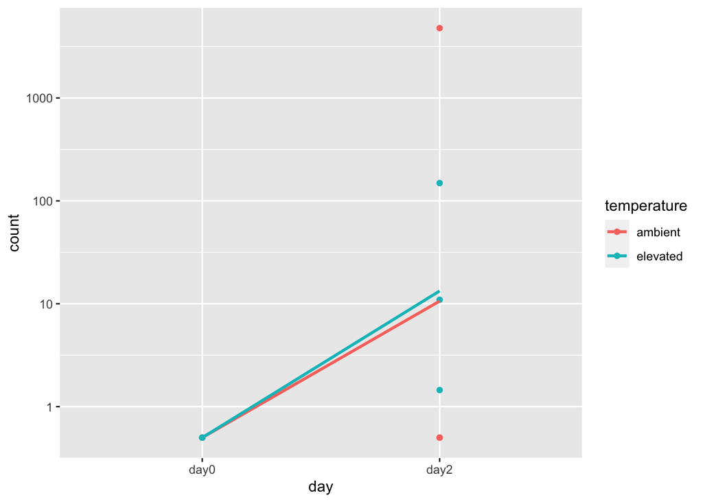

```r
data <- plotCounts(abcghi.dds, which.min(abcghi.res$pvalue),
                   intgroup = c("day","temperature"), returnData = TRUE)
ggplot(data, aes(x=day, y=count, color = temperature, group=temperature)) +
  geom_point() + stat_smooth(se=FALSE,method="loess") + scale_y_log10()
```

```r
# Count number of hits with adjusted p-value less then 0.05
dim(abcghi.res[!is.na(abcghi.res$padj) & abcghi.res$padj <= 0.05, ])
```

```
## [1] 137   6
```

137 degs comparing time while taking temp into account

Write out list of 137 DEGs:

```r
write.table(abcghi.res.sig, "../analyses/DEGlist-abcghi-daytemp.tab", sep = '\t', quote = FALSE, row.names = TRUE, col.names = TRUE)
```

## `join` with count data to make a heatmap:

read in .txt version

```r
daytemp_degs <- read.delim("../analyses/DEGlist-abcghi-daytemp.txt", sep = '\t')
head(daytemp_degs)
```

```
##                Trinity_ID baseMean log2FoldChange    lfcSE      stat
## 1 TRINITY_DN3409_c0_g1_i1 63.71316       8.344450 2.387571  3.494953
## 2 TRINITY_DN2313_c0_g2_i6 99.68389      -5.045874 1.363285 -3.701262
## 3 TRINITY_DN8225_c0_g1_i1 32.63748       7.909505 2.368427  3.339560
## 4 TRINITY_DN1142_c0_g1_i1 97.14860      -8.917549 2.548056 -3.499746
## 5 TRINITY_DN1793_c1_g1_i5 86.27876       7.148545 2.143754  3.334591
## 6 TRINITY_DN8127_c0_g1_i7 67.04734       9.287082 2.608399  3.560454
##        pvalue       padj
## 1 0.000474145 0.03857132
## 2 0.000214530 0.02971237
## 3 0.000839113 0.04817265
## 4 0.000465701 0.03857132
## 5 0.000854248 0.04817265
## 6 0.000370215 0.03760890
```

Make row names of abcghi Trinity IDs into a column called “Trinity_ID”:

```r
#make Trinity IDs into a column in tmdf
df <- abcghi
names <- rownames(abcghi)
rownames(df) <- NULL
data <- cbind(names, df)

#rename column 1 in tmdf
colnames(data) <- c("Trinity_ID", "CrabA_0", "CrabB_0", "CrabC_0", "CrabA_2", "CrabB_2", "CrabC_2", "CrabG_0", "CrabH_0", "CrabI_0", "CrabG_2", "CrabH_2", "CrabI_2")
head(data)
```

```
##                 Trinity_ID CrabA_0 CrabB_0 CrabC_0 CrabA_2 CrabB_2 CrabC_2
## 1  TRINITY_DN5772_c0_g1_i1       0       0       0       3       0       0
## 2  TRINITY_DN2201_c0_g1_i1       0       0       0       0       0       0
## 3  TRINITY_DN4656_c0_g1_i1      37       4       7      35       0       3
## 4  TRINITY_DN7591_c0_g1_i1       3       2       0      25       0       0
## 5  TRINITY_DN6285_c0_g1_i4       0       0       0       0       0       0
## 6 TRINITY_DN28918_c0_g1_i1       2       0       0       0       0       0
##   CrabG_0 CrabH_0 CrabI_0 CrabG_2 CrabH_2 CrabI_2
## 1       0       0       0       0       0       0
## 2       0       0       0       0       5       6
## 3      74       7      18       0      19       4
## 4       0       0      41       0      16       2
## 5       0       0       0       0       0       0
## 6       0       0       1       0       0       0
```

`join` based on Trinity ID

```r
daytemp_degs_counts <- left_join(data, daytemp_degs, by = "Trinity_ID")
head(daytemp_degs_counts)
```

```
##                 Trinity_ID CrabA_0 CrabB_0 CrabC_0 CrabA_2 CrabB_2 CrabC_2
## 1  TRINITY_DN5772_c0_g1_i1       0       0       0       3       0       0
## 2  TRINITY_DN2201_c0_g1_i1       0       0       0       0       0       0
## 3  TRINITY_DN4656_c0_g1_i1      37       4       7      35       0       3
## 4  TRINITY_DN7591_c0_g1_i1       3       2       0      25       0       0
## 5  TRINITY_DN6285_c0_g1_i4       0       0       0       0       0       0
## 6 TRINITY_DN28918_c0_g1_i1       2       0       0       0       0       0
##   CrabG_0 CrabH_0 CrabI_0 CrabG_2 CrabH_2 CrabI_2 baseMean log2FoldChange lfcSE
## 1       0       0       0       0       0       0       NA             NA    NA
## 2       0       0       0       0       5       6       NA             NA    NA
## 3      74       7      18       0      19       4       NA             NA    NA
## 4       0       0      41       0      16       2       NA             NA    NA
## 5       0       0       0       0       0       0       NA             NA    NA
## 6       0       0       1       0       0       0       NA             NA    NA
##   stat pvalue padj
## 1   NA     NA   NA
## 2   NA     NA   NA
## 3   NA     NA   NA
## 4   NA     NA   NA
## 5   NA     NA   NA
## 6   NA     NA   NA
```

Only want the ones that match!

```r
daytemp_degs_counts_match <- filter(daytemp_degs_counts, baseMean != "NA")
head(daytemp_degs_counts_match)
```

```
##                Trinity_ID CrabA_0 CrabB_0 CrabC_0 CrabA_2 CrabB_2 CrabC_2
## 1 TRINITY_DN3409_c0_g1_i1       0       0       0       6      14       0
## 2 TRINITY_DN2313_c0_g2_i6     365     116      75       3       0       5
## 3 TRINITY_DN8225_c0_g1_i1       0       0       0       4       7       0
## 4 TRINITY_DN1142_c0_g1_i1     214       0     630       0       0       0
## 5 TRINITY_DN1793_c1_g1_i5       0       0       3       8      18       0
## 6 TRINITY_DN8127_c0_g1_i7       0       0       0       0      14       0
##   CrabG_0 CrabH_0 CrabI_0 CrabG_2 CrabH_2 CrabI_2 baseMean log2FoldChange
## 1       0       0       0       2       1       5 63.71316       8.344450
## 2     571     291     106       5       1       1 99.68389      -5.045874
## 3       0       0       0       1       1      12 32.63748       7.909505
## 4     705       0      77       0       0       0 97.14860      -8.917549
## 5       0       0       4       9       1      36 86.27876       7.148545
## 6       0       0       0       6       4      34 67.04734       9.287082
##      lfcSE      stat      pvalue       padj
## 1 2.387571  3.494953 0.000474145 0.03857132
## 2 1.363285 -3.701262 0.000214530 0.02971237
## 3 2.368427  3.339560 0.000839113 0.04817265
## 4 2.548056 -3.499746 0.000465701 0.03857132
## 5 2.143754  3.334591 0.000854248 0.04817265
## 6 2.608399  3.560454 0.000370215 0.03760890
```

Set Trinity_ID as row names:

```r
rownames(daytemp_degs_counts_match) <- daytemp_degs_counts_match$Trinity_ID #set Trinity IDs as rownames
daytemp_degs_counts_match.heatmap <- daytemp_degs_counts_match[,-1] #remove redundant column
head(daytemp_degs_counts_match.heatmap)
```

```
##                         CrabA_0 CrabB_0 CrabC_0 CrabA_2 CrabB_2 CrabC_2 CrabG_0
## TRINITY_DN3409_c0_g1_i1       0       0       0       6      14       0       0
## TRINITY_DN2313_c0_g2_i6     365     116      75       3       0       5     571
## TRINITY_DN8225_c0_g1_i1       0       0       0       4       7       0       0
## TRINITY_DN1142_c0_g1_i1     214       0     630       0       0       0     705
## TRINITY_DN1793_c1_g1_i5       0       0       3       8      18       0       0
## TRINITY_DN8127_c0_g1_i7       0       0       0       0      14       0       0
##                         CrabH_0 CrabI_0 CrabG_2 CrabH_2 CrabI_2 baseMean
## TRINITY_DN3409_c0_g1_i1       0       0       2       1       5 63.71316
## TRINITY_DN2313_c0_g2_i6     291     106       5       1       1 99.68389
## TRINITY_DN8225_c0_g1_i1       0       0       1       1      12 32.63748
## TRINITY_DN1142_c0_g1_i1       0      77       0       0       0 97.14860
## TRINITY_DN1793_c1_g1_i5       0       4       9       1      36 86.27876
## TRINITY_DN8127_c0_g1_i7       0       0       6       4      34 67.04734
##                         log2FoldChange    lfcSE      stat      pvalue
## TRINITY_DN3409_c0_g1_i1       8.344450 2.387571  3.494953 0.000474145
## TRINITY_DN2313_c0_g2_i6      -5.045874 1.363285 -3.701262 0.000214530
## TRINITY_DN8225_c0_g1_i1       7.909505 2.368427  3.339560 0.000839113
## TRINITY_DN1142_c0_g1_i1      -8.917549 2.548056 -3.499746 0.000465701
## TRINITY_DN1793_c1_g1_i5       7.148545 2.143754  3.334591 0.000854248
## TRINITY_DN8127_c0_g1_i7       9.287082 2.608399  3.560454 0.000370215
##                               padj
## TRINITY_DN3409_c0_g1_i1 0.03857132
## TRINITY_DN2313_c0_g2_i6 0.02971237
## TRINITY_DN8225_c0_g1_i1 0.04817265
## TRINITY_DN1142_c0_g1_i1 0.03857132
## TRINITY_DN1793_c1_g1_i5 0.04817265
## TRINITY_DN8127_c0_g1_i7 0.03760890
```

Pull out just the sample count data:

```r
daytemp_degs_counts_match.heatmap <- select(daytemp_degs_counts_match.heatmap, CrabA_0, CrabB_0, CrabC_0, CrabA_2, CrabB_2, CrabC_2, CrabG_0, CrabH_0, CrabI_0, CrabG_2, CrabH_2, CrabI_2)
head(daytemp_degs_counts_match.heatmap)
```

```
##                         CrabA_0 CrabB_0 CrabC_0 CrabA_2 CrabB_2 CrabC_2 CrabG_0
## TRINITY_DN3409_c0_g1_i1       0       0       0       6      14       0       0
## TRINITY_DN2313_c0_g2_i6     365     116      75       3       0       5     571
## TRINITY_DN8225_c0_g1_i1       0       0       0       4       7       0       0
## TRINITY_DN1142_c0_g1_i1     214       0     630       0       0       0     705
## TRINITY_DN1793_c1_g1_i5       0       0       3       8      18       0       0
## TRINITY_DN8127_c0_g1_i7       0       0       0       0      14       0       0
##                         CrabH_0 CrabI_0 CrabG_2 CrabH_2 CrabI_2
## TRINITY_DN3409_c0_g1_i1       0       0       2       1       5
## TRINITY_DN2313_c0_g2_i6     291     106       5       1       1
## TRINITY_DN8225_c0_g1_i1       0       0       1       1      12
## TRINITY_DN1142_c0_g1_i1       0      77       0       0       0
## TRINITY_DN1793_c1_g1_i5       0       4       9       1      36
## TRINITY_DN8127_c0_g1_i7       0       0       6       4      34
```

Going to remove all rows that have “0” for all samples:

```r
noz_daytemp_degs_counts_match.heatmap <- daytemp_degs_counts_match.heatmap[rowSums(daytemp_degs_counts_match.heatmap[, -1] >0) !=0, ]
head(noz_daytemp_degs_counts_match.heatmap)
```

```
##                         CrabA_0 CrabB_0 CrabC_0 CrabA_2 CrabB_2 CrabC_2 CrabG_0
## TRINITY_DN3409_c0_g1_i1       0       0       0       6      14       0       0
## TRINITY_DN2313_c0_g2_i6     365     116      75       3       0       5     571
## TRINITY_DN8225_c0_g1_i1       0       0       0       4       7       0       0
## TRINITY_DN1142_c0_g1_i1     214       0     630       0       0       0     705
## TRINITY_DN1793_c1_g1_i5       0       0       3       8      18       0       0
## TRINITY_DN8127_c0_g1_i7       0       0       0       0      14       0       0
##                         CrabH_0 CrabI_0 CrabG_2 CrabH_2 CrabI_2
## TRINITY_DN3409_c0_g1_i1       0       0       2       1       5
## TRINITY_DN2313_c0_g2_i6     291     106       5       1       1
## TRINITY_DN8225_c0_g1_i1       0       0       1       1      12
## TRINITY_DN1142_c0_g1_i1       0      77       0       0       0
## TRINITY_DN1793_c1_g1_i5       0       4       9       1      36
## TRINITY_DN8127_c0_g1_i7       0       0       6       4      34
```

```r
heatmapPurpleOrange <- RColorBrewer::brewer.pal(11, "PuOr")
```

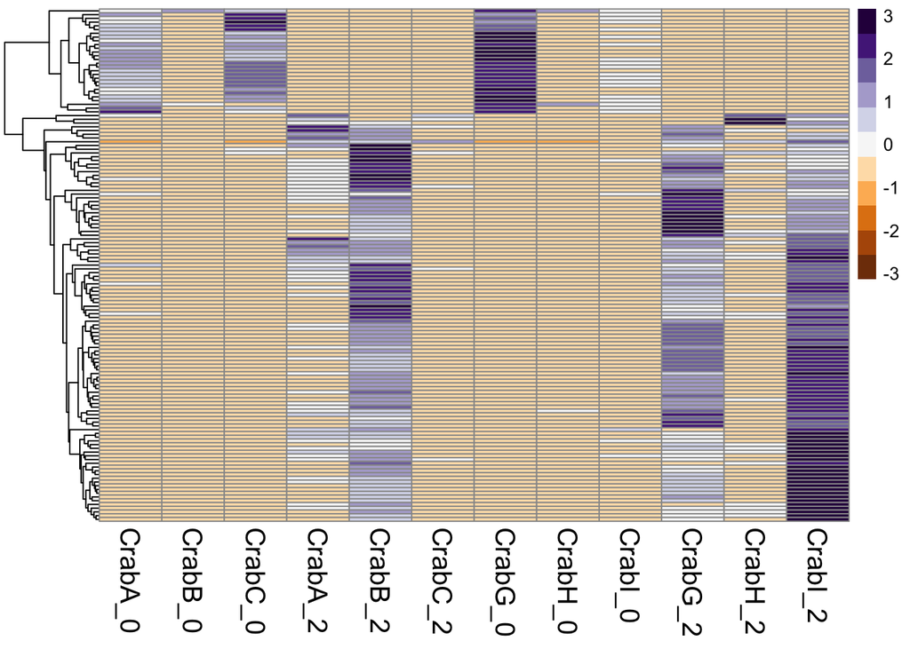

```r
pheatmap(noz_daytemp_degs_counts_match.heatmap, scale = "row", cluster_row = TRUE, cluster_cols = FALSE, clustering_distance_rows = "euclidean", clustering_method = "average", show_rownames = FALSE, show_colnames = TRUE, treeheight_col = 80, legend = TRUE, color = heatmapPurpleOrange, fontsize_col = 15, fontsize_row = 12)
```

Pull out just the sample count data:

```r
daytemp_degs_counts_match.heatmap2 <- select(daytemp_degs_counts_match.heatmap, CrabA_0, CrabB_0, CrabC_0,  CrabG_0, CrabH_0, CrabI_0, CrabA_2, CrabB_2, CrabC_2, CrabG_2, CrabH_2, CrabI_2)
head(daytemp_degs_counts_match.heatmap2)
```

```
##                         CrabA_0 CrabB_0 CrabC_0 CrabG_0 CrabH_0 CrabI_0 CrabA_2
## TRINITY_DN3409_c0_g1_i1       0       0       0       0       0       0       6
## TRINITY_DN2313_c0_g2_i6     365     116      75     571     291     106       3
## TRINITY_DN8225_c0_g1_i1       0       0       0       0       0       0       4
## TRINITY_DN1142_c0_g1_i1     214       0     630     705       0      77       0
## TRINITY_DN1793_c1_g1_i5       0       0       3       0       0       4       8
## TRINITY_DN8127_c0_g1_i7       0       0       0       0       0       0       0
##                         CrabB_2 CrabC_2 CrabG_2 CrabH_2 CrabI_2
## TRINITY_DN3409_c0_g1_i1      14       0       2       1       5
## TRINITY_DN2313_c0_g2_i6       0       5       5       1       1
## TRINITY_DN8225_c0_g1_i1       7       0       1       1      12
## TRINITY_DN1142_c0_g1_i1       0       0       0       0       0
## TRINITY_DN1793_c1_g1_i5      18       0       9       1      36
## TRINITY_DN8127_c0_g1_i7      14       0       6       4      34
```

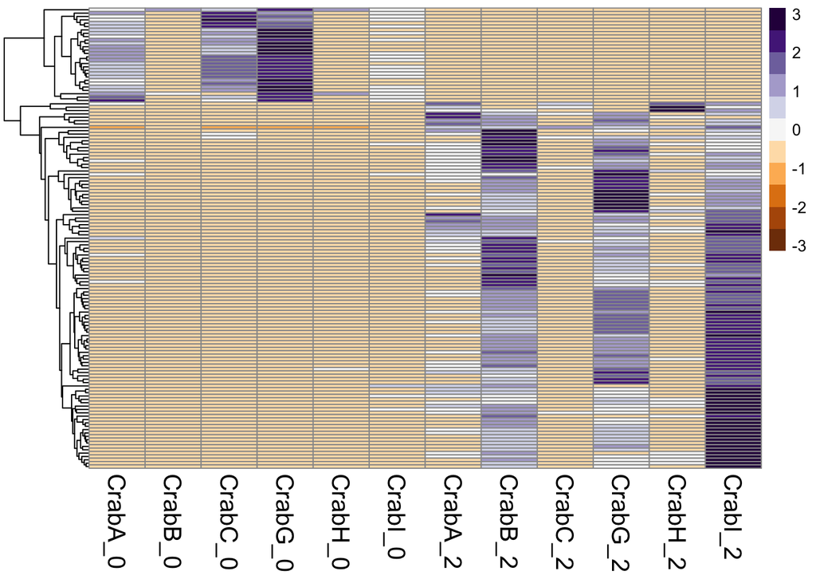

```r
pheatmap(daytemp_degs_counts_match.heatmap2, scale = "row", cluster_row = TRUE, cluster_cols = FALSE, clustering_distance_rows = "euclidean", clustering_method = "average", show_rownames = FALSE, show_colnames = TRUE, treeheight_col = 80, legend = TRUE, color = heatmapPurpleOrange, fontsize_col = 15, fontsize_row = 12)
```

## Do contrast between the different temperatures:

```r
deseq2.resTemp <- results(abcghi.dds,
                          contrast = c("temperature", "ambient",  "elevated"))
head(deseq2.resTemp)
```

```
## log2 fold change (MLE): temperature ambient vs elevated
## Wald test p-value: temperature ambient vs elevated
## DataFrame with 6 rows and 6 columns
##                                    baseMean     log2FoldChange            lfcSE
##                                   <numeric>          <numeric>        <numeric>
## TRINITY_DN5772_c0_g1_i1  0.0591488894177097   1.17861195893643 3.07941486711716
## TRINITY_DN2201_c0_g1_i1    0.57340997057478 -0.539698675437303 3.04929913306982
## TRINITY_DN4656_c0_g1_i1    10.6754338893376 -0.592726714818408 1.34597682387634
## TRINITY_DN7591_c0_g1_i1    2.38416572691185 -0.584943376796543 2.13947715428865
## TRINITY_DN6285_c0_g1_i4                   0                 NA               NA
## TRINITY_DN28918_c0_g1_i1 0.0714524148702473    1.0175498835767 3.07136729284889
##                                        stat            pvalue              padj
##                                   <numeric>         <numeric>         <numeric>
## TRINITY_DN5772_c0_g1_i1   0.382738932490705 0.701913344521808 0.999839511218817
## TRINITY_DN2201_c0_g1_i1  -0.176991056595347 0.859515414480362 0.999839511218817
## TRINITY_DN4656_c0_g1_i1  -0.440369183409406                NA                NA
## TRINITY_DN7591_c0_g1_i1  -0.273404824923699 0.784542044278896 0.999839511218817
## TRINITY_DN6285_c0_g1_i4                  NA                NA                NA
## TRINITY_DN28918_c0_g1_i1  0.331301920791393 0.740416440577219 0.999839511218817
```

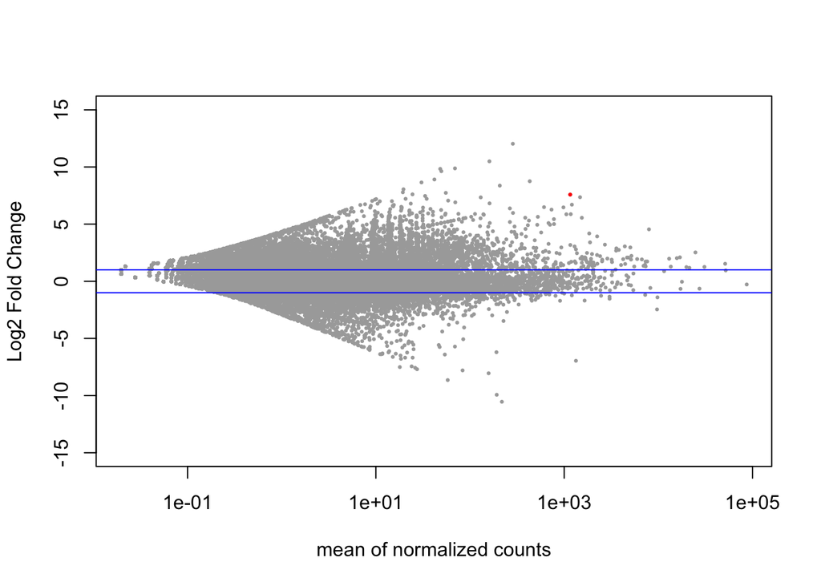

```r
tmp <- deseq2.resTemp
# The main plot
plot(tmp$baseMean, tmp$log2FoldChange, pch=20, cex=0.45, ylim=c(-15, 15), log="x", col="darkgray",
     #main="Infection Status  (pval </= 0.05)",
     xlab="mean of normalized counts",
     ylab="Log2 Fold Change")
# Getting the significant points and plotting them again so they're a different color
tmp.sig <- deseq2.resTemp[!is.na(deseq2.resTemp$padj) & deseq2.resTemp$padj <= 0.05, ]
points(tmp.sig$baseMean, tmp.sig$log2FoldChange, pch=20, cex=0.45, col="red")
# 2 FC lines
abline(h=c(-1,1), col="blue")
```

```r
# Count number of hits with adjusted p-value less then 0.05
dim(deseq2.resTemp[!is.na(deseq2.resTemp$padj) & deseq2.resTemp$padj <= 0.05, ])
```

```
## [1] 2 6
```

2 DEGs

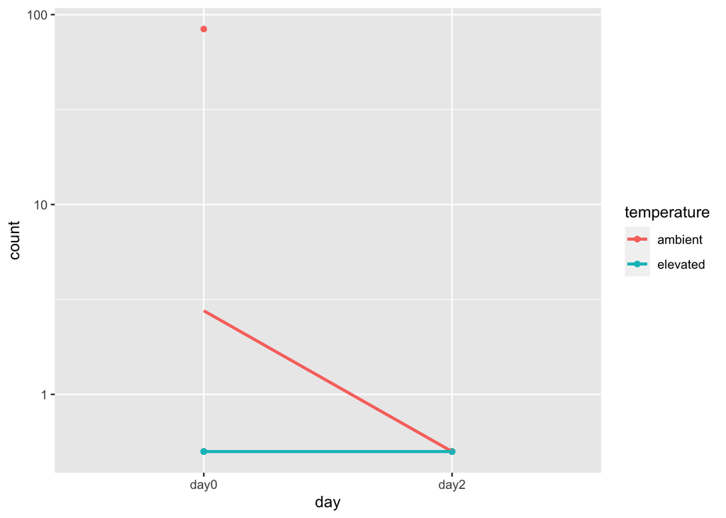

```r
data <- plotCounts(abcghi.dds, which.min(deseq2.resTemp$pvalue),
                   intgroup = c("day","temperature"), returnData = TRUE)
ggplot(data, aes(x=day, y=count, color = temperature, group=temperature)) +
  geom_point() + stat_smooth(se=FALSE,method="loess") + scale_y_log10()
```

## Try time series of just crab ABC genes over time:

Subset those columns:

```r
abc <- select(indiv_counts, CrabA_0, CrabB_0, CrabC_0, CrabA_2, CrabB_2, CrabC_2, CrabA_17, CrabB_17, CrabC_17)
head(abc)
```

```
##                          CrabA_0 CrabB_0 CrabC_0 CrabA_2 CrabB_2 CrabC_2
## TRINITY_DN5772_c0_g1_i1        0       0       0       3       0       0
## TRINITY_DN2201_c0_g1_i1        0       0       0       0       0       0
## TRINITY_DN4656_c0_g1_i1       37       4       7      35       0       3
## TRINITY_DN7591_c0_g1_i1        3       2       0      25       0       0
## TRINITY_DN6285_c0_g1_i4        0       0       0       0       0       0
## TRINITY_DN28918_c0_g1_i1       2       0       0       0       0       0
##                          CrabA_17 CrabB_17 CrabC_17
## TRINITY_DN5772_c0_g1_i1         0        0        0
## TRINITY_DN2201_c0_g1_i1         0        0        0
## TRINITY_DN4656_c0_g1_i1         0        8       12
## TRINITY_DN7591_c0_g1_i1         0       15        1
## TRINITY_DN6285_c0_g1_i4         0        0        4
## TRINITY_DN28918_c0_g1_i1        0        1        0
```

```r
abc.colData <- data.frame(crab=factor(c("crabA", "crabB", "crabC", "crabA", "crabB", "crabC", "crabA", "crabB", "crabC")),
                             day=factor(c(rep("day0", 3), rep("day02", 3), rep("day17", 3))))
rownames(abc.colData) <- colnames(abc)
abc.dds <- DESeqDataSetFromMatrix(countData = abc,
                                     colData = abc.colData,
                                     design = ~ day)
abc.dds <- DESeq(abc.dds)
abc.res <- results(abc.dds)
abc.res$symbol <- mcols(abc.dds)$symbol
head(abc.res[order(abc.res$pvalue),],4)
```

```
## log2 fold change (MLE): day day17 vs day0
## Wald test p-value: day day17 vs day0
## DataFrame with 4 rows and 6 columns
##                                 baseMean   log2FoldChange            lfcSE
##                                <numeric>        <numeric>        <numeric>
## TRINITY_DN57_c0_g3_i1   469.564942195019 28.1633312893289 3.78045259821233
## TRINITY_DN1125_c0_g1_i1 530.311373598606 25.8550984567282 3.55762914234894
## TRINITY_DN1454_c0_g1_i8 40.1125098505044 23.3245353790885 3.30742960689406
## TRINITY_DN572_c0_g1_i12 447.617573015448 22.5023705867466  3.2849671883926
##                                     stat               pvalue
##                                <numeric>            <numeric>
## TRINITY_DN57_c0_g3_i1   7.44972475058848 9.35351700294067e-14
## TRINITY_DN1125_c0_g1_i1 7.26750805724998 3.66179502355425e-13
## TRINITY_DN1454_c0_g1_i8 7.05216381037117 1.76156642207213e-12
## TRINITY_DN572_c0_g1_i12 6.85010512928668 7.37957365140277e-12
##                                         padj
##                                    <numeric>
## TRINITY_DN57_c0_g3_i1   3.42525792647687e-10
## TRINITY_DN1125_c0_g1_i1 6.70474668812782e-10
## TRINITY_DN1454_c0_g1_i8 2.15028541254272e-09
## TRINITY_DN572_c0_g1_i12 6.75599967785923e-09
```

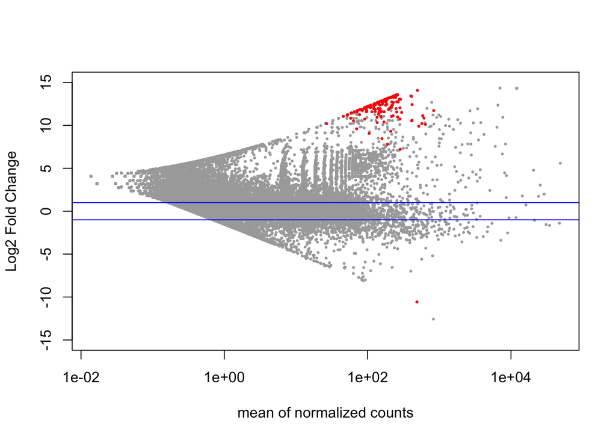

```r
day <- abc.res
# The main plot
plot(day$baseMean, day$log2FoldChange, pch=20, cex=0.45, ylim=c(-15, 15), log="x", col="darkgray",
     #main="Infection Status  (pval </= 0.05)",
     xlab="mean of normalized counts",
     ylab="Log2 Fold Change")
# Getting the significant points and plotting them again so they're a different color
day.sig <- abc.res[!is.na(abc.res$padj) & abc.res$padj <= 0.05, ]
points(day.sig$baseMean, day.sig$log2FoldChange, pch=20, cex=0.45, col="red")
# 2 FC lines
abline(h=c(-1,1), col="blue")
```

```r
# Count number of hits with adjusted p-value less then 0.05
dim(abc.res[!is.na(abc.res$padj) & abc.res$padj <= 0.05, ])
```

```
## [1] 184   6
```

184

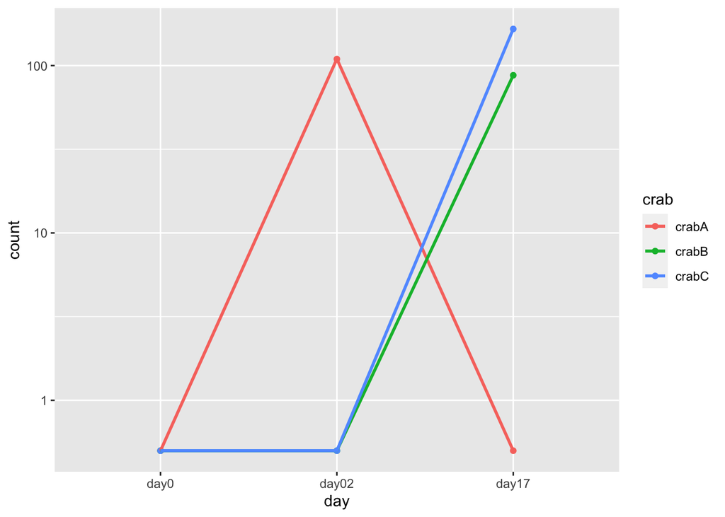

```r
data <- plotCounts(abc.dds, "TRINITY_DN1454_c0_g1_i8",
                   intgroup=c("day","crab"), returnData=TRUE)
ggplot(data, aes(x=day, y=count, color=crab, group=crab)) +
  geom_point() + stat_smooth(se=FALSE,method="loess") +  scale_y_log10()
```

^ Can plot only one gene at a time for this plot. Plot gene of interest.

```r
resultsNames(abc.dds)
```

```
## [1] "Intercept"         "day_day02_vs_day0" "day_day17_vs_day0"
```

```r
betas <- coef(abc.dds)
colnames(betas)
```

```
## [1] "Intercept"         "day_day02_vs_day0" "day_day17_vs_day0"
```

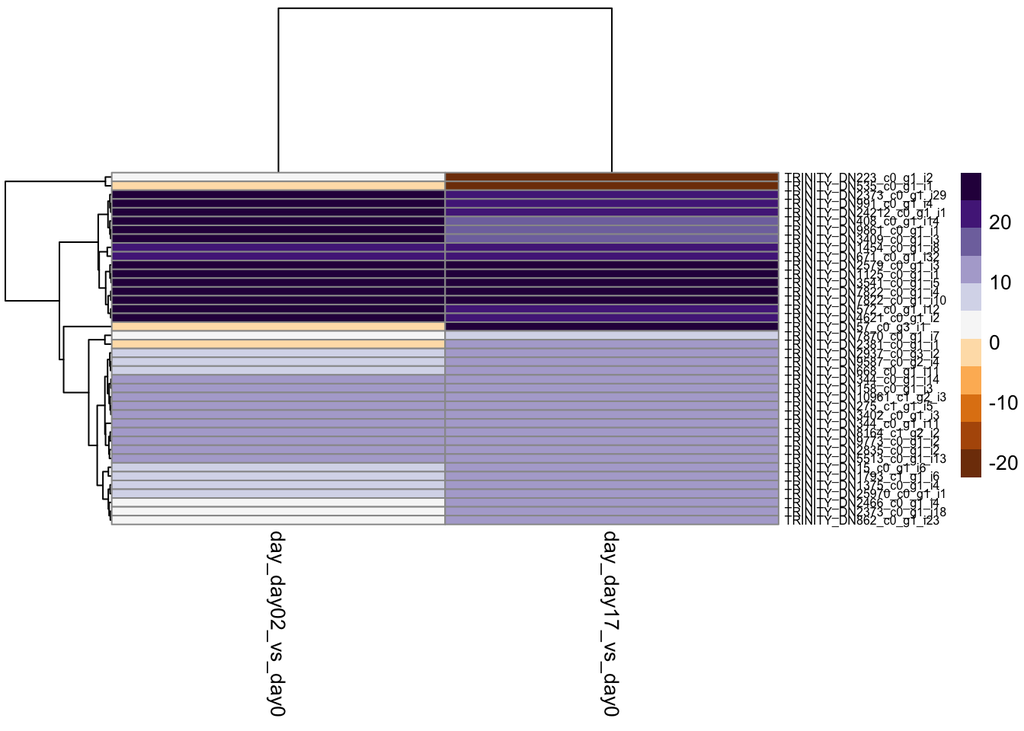

```r
mat <- betas[, -1]
topGenes <- head(order(abc.res$pvalue),40)
colors <- RColorBrewer::brewer.pal(11, "PuOr")
pheatmap(mat [topGenes, ],  clustering_distance_rows = "euclidean", clustering_method = "average", treeheight_col = 80, legend = TRUE, color = colors, fontsize_col = 10, fontsize_row = 6)
```

## Try to figure out what genes are doing things over time in crabs ABC

Remove rows that have conts of ‘0’ all across:

```r
abc_noz <- abc[rowSums(abc[, -1] >0) !=0, ]
head(abc_noz)
```

```
##                          CrabA_0 CrabB_0 CrabC_0 CrabA_2 CrabB_2 CrabC_2
## TRINITY_DN5772_c0_g1_i1        0       0       0       3       0       0
## TRINITY_DN4656_c0_g1_i1       37       4       7      35       0       3
## TRINITY_DN7591_c0_g1_i1        3       2       0      25       0       0
## TRINITY_DN6285_c0_g1_i4        0       0       0       0       0       0
## TRINITY_DN28918_c0_g1_i1       2       0       0       0       0       0
## TRINITY_DN814_c0_g1_i9         0       0       1       0       0       0
##                          CrabA_17 CrabB_17 CrabC_17
## TRINITY_DN5772_c0_g1_i1         0        0        0
## TRINITY_DN4656_c0_g1_i1         0        8       12
## TRINITY_DN7591_c0_g1_i1         0       15        1
## TRINITY_DN6285_c0_g1_i4         0        0        4
## TRINITY_DN28918_c0_g1_i1        0        1        0
## TRINITY_DN814_c0_g1_i9          0        0        0
```

30,186 rows

Then, remove rows that have ’0’s in any sample:

```r
row_sub = apply(abc_noz, 1, function(row) all(row !=0 ))
abc_nozs <- abc_noz[row_sub,]
head(abc_nozs)
```

```
##                          CrabA_0 CrabB_0 CrabC_0 CrabA_2 CrabB_2 CrabC_2
## TRINITY_DN4985_c0_g1_i1       39       7      29      23       7      12
## TRINITY_DN11674_c6_g1_i1   10463    2290    2143    4607      13    2251
## TRINITY_DN4670_c0_g1_i1      348     178     266    3438       3      19
## TRINITY_DN28_c2_g1_i1       1229      51     165    1338       4       7
## TRINITY_DN23876_c0_g1_i1    1401    1256    1508    1779       3     940
## TRINITY_DN8361_c1_g1_i1      921    1111     904    1199       2     934
##                          CrabA_17 CrabB_17 CrabC_17
## TRINITY_DN4985_c0_g1_i1         1       11       23
## TRINITY_DN11674_c6_g1_i1        7     1362     1696
## TRINITY_DN4670_c0_g1_i1         5     3057     2491
## TRINITY_DN28_c2_g1_i1           2      234      319
## TRINITY_DN23876_c0_g1_i1        2      374      806
## TRINITY_DN8361_c1_g1_i1         4      328      303
```

502 rows

```r
abc_nozs.heatmap <- select(abc_nozs, "CrabA_0", "CrabA_2", "CrabA_17", "CrabB_0", "CrabB_2", "CrabB_17", "CrabC_0", "CrabC_2", "CrabC_17")
head(abc_nozs.heatmap)
```

```
##                          CrabA_0 CrabA_2 CrabA_17 CrabB_0 CrabB_2 CrabB_17
## TRINITY_DN4985_c0_g1_i1       39      23        1       7       7       11
## TRINITY_DN11674_c6_g1_i1   10463    4607        7    2290      13     1362
## TRINITY_DN4670_c0_g1_i1      348    3438        5     178       3     3057
## TRINITY_DN28_c2_g1_i1       1229    1338        2      51       4      234
## TRINITY_DN23876_c0_g1_i1    1401    1779        2    1256       3      374
## TRINITY_DN8361_c1_g1_i1      921    1199        4    1111       2      328
##                          CrabC_0 CrabC_2 CrabC_17
## TRINITY_DN4985_c0_g1_i1       29      12       23
## TRINITY_DN11674_c6_g1_i1    2143    2251     1696
## TRINITY_DN4670_c0_g1_i1      266      19     2491
## TRINITY_DN28_c2_g1_i1        165       7      319
## TRINITY_DN23876_c0_g1_i1    1508     940      806
## TRINITY_DN8361_c1_g1_i1      904     934      303
```

```r
heatmapPurOr <- RColorBrewer::brewer.pal(11, "PuOr")
```

Create a heatmap of those count data:

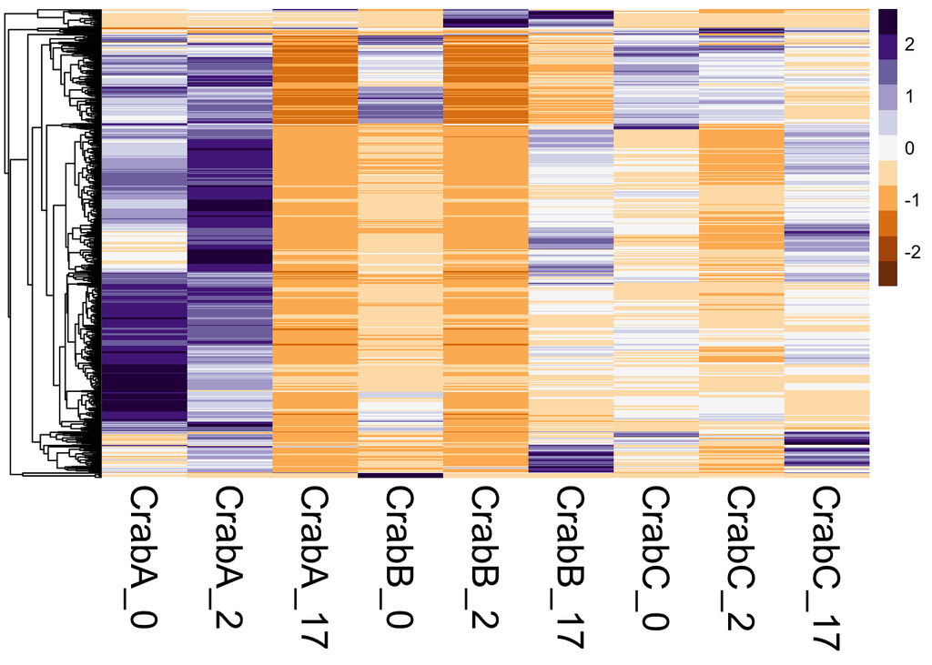

```r
pheatmap(abc_nozs.heatmap, scale = "row", cluster_row = TRUE, cluster_cols = FALSE, clustering_distance_rows = "euclidean", clustering_method = "average", show_rownames = FALSE, show_colnames = TRUE, treeheight_col = 80, legend = TRUE, color = heatmapPurOr, fontsize_col = 20, fontsize_row = 12)
```

## Try all again, but with different individual samples:

I’ll go with A vs E time points 0 and 2 and 17. Subset those columns:

```r
#ave <- select(indiv_counts, CrabA_0, CrabA_2, CrabA_17, CrabE_0, CrabE_2, CrabE_17)
#head(ave)
```

```r
#ave.colData <- data.frame(temperature=factor(c(rep("ambient", 3), rep("decreased", 3))),
#                             day=factor(c("day0", "day02", "day17", "day0", "day02", "day17")))
#rownames(ave.colData) <- colnames(ave)
#ave.dds <- DESeqDataSetFromMatrix(countData = ave,
#                                     colData = ave.colData,
#                                     design = ~ temperature + day)
```

```r
#design(ave.dds) <- formula( ~ temperature + day)
#ave.dds <- DESeq(ave.dds)
#ave.res <- results(ave.dds)
#ave.res$symbol <- mcols(ave.dds)$symbol
#head(ave.res[order(ave.res$pvalue),],4)
```

```r
#ave.res <- ave.res
# The main plot
#plot(ave.res$baseMean, ave.res$log2FoldChange, pch=20, cex=0.45, ylim=c(-15, 15), log="x", col="darkgray",
     #main="Infection Status  (pval </= 0.05)",
#     xlab="mean of normalized counts",
#     ylab="Log2 Fold Change")
# Getting the significant points and plotting them again so they're a different color
#ave.res.sig <- ave.res[!is.na(ave.res$padj) & ave.res$padj <= 0.05, ]
#points(ave.res.sig$baseMean, ave.res.sig$log2FoldChange, pch=20, cex=0.45, col="red")
# 2 FC lines
#abline(h=c(-1,1), col="blue")
```

```r
#write.table(ave.res.sig, "../analyses/DEGlist-ave-timeseries.tab", sep = "\t", row.names = T, quote = FALSE, col.names = TRUE)
```

```r
#data <- plotCounts(ave.dds, which.min(ave.res$pvalue),
#                   intgroup = c("day","temperature"), returnData = TRUE)
#ggplot(data, aes(x=day, y=count, color = temperature, group=temperature)) +
#  geom_point() + stat_smooth(se=FALSE,method="loess") + scale_y_log10()
```

```r
#ave.betas <- coef(ave.dds)
#colnames(ave.betas)
```

Don’t understand this next chunk of code… why are only two columns showing?

```r
#mat <- ave.betas[,-c(1,2)]
#mat[mat < -5] <- -5
#mat[mat > 5] <- 5
#topGenes <- head(order(ave.res$pvalue),10)
#colors <- RColorBrewer::brewer.pal(11, "PuOr")
#pheatmap(mat [topGenes, ],  clustering_distance_rows = "euclidean", clustering_method = "average", treeheight_col = 80, legend = TRUE, color = colors, fontsize_col = 10, fontsize_row = 6, ColV=FALSE)
```